# **Reviewer Comment. V. 2**

# General feedback: Hello, Jolene Glenn! I'm glad to tell you that your project is perfect now! Thank you for the corrections👍 It has been accepted, great! 😄 Keep up the good work, and good luck! :)

# **Reviewer Comment**

**Hello! I am Larchenko Ksenia and I'm glad to review your project**!

You can find my comments in green, yellow and red boxes like these:

**Success:** green color shows that everything is done perfectly;

**Remark & Recommendation:** yellow color highlights something to pay attention for;

**Needs fixing:** if the color is red, please rework.

**Please, don't remove my comments:)**

# **Reviewer Comment. V.1**

**General feedback :** * Thank you for sending your project. You've done a really good job on it! * Different important methods for working with data were used **(info, describe, pivot_table, apply and others)**! It is really great that you can apply these methods on practice, keep it up! * I like conclusions and that most the steps you took were well-commented in your project. * It was very interesting to check your project and follow your thought. * The work itself is at a good level! 🙂

# **~Reviewer Comment. V.1~**

**General feedback:** * I appreciate the amount of work you've done! It is the amazing job! **There are a couple of things that need to be done before your project is complete (please, check the 4th step )**. Project can't be accepted with comments in the red boxes, * But all mistakes can be easily fixed, ~Waiting for your corrections 😉~ Also I've left an "Remark & Recommendation" comment/s, which could help you to upgrade/boost/polish your project and further develop your skills. It doesn't mean that you've done something wrong, it just contains some advice on how it could be improved:)

**For your future projects:** * It is better to briefly describe the main findings at the end of **each step**. * Technical strings like `` can be deleted with the use of `plt.show()` method (if it occurs). It will improve the visualization in the project:) * Please, note that we can avoid warnings (if necessary) by using the code below. `import sys import warnings if not sys.warnoptions: warnings.simplefilter("ignore")` * For a real life report it would be great to write **all steps** in a structured way. For example: 1. **In the data's preparation & processing stage**: * We observed missing values ..; * We removed duplicates.. 2. **In the exploratory data analysis stage**: * 3. etc.

# Research on car sales ads

You're an analyst at Crankshaft List. Hundreds of free advertisements for vehicles are published on your site every day.

You need to study data collected over the last few years and determine which factors influence the price of a vehicle.

# **Reviewer Comment**

**Recommendation:** It is great that you started the project with short introduction, but it is also valuable to provide a description of the columns used and the content plan of the main steps of the analysis:)

## Open the data file and study the general information.

*Import libraries and packages*

```python
import pandas as pd
import matplotlib.pyplot as plt
```

# **Reviewer Comment**

**Success:** Importing all libraries in the first separate cell is a good habit👍

*Examine the original data*

- Review the data's general information and column's subcategories

```python
# Read and save original data
vehicle_ads_orig = pd.read_csv('/datasets/vehicles_us.csv')

# Examine first 20 rows
print('First 20 rows of original data:')
vehicle_ads_orig.head(20)
```

```
First 20 rows of original data:
```

|  | price | model_year | model | condition | cylinders | fuel | odometer | transmission | type | paint_color | is_4wd | date_posted | days_listed |
| --- | --- | --- | --- | --- | --- | --- | --- | --- | --- | --- | --- | --- | --- |
| 0 | 9400 | 2011.0 | bmw x5 | good | 6.0 | gas | 145000.0 | automatic | SUV | NaN | 1.0 | 2018-06-23 | 19 |
| 1 | 25500 | NaN | ford f-150 | good | 6.0 | gas | 88705.0 | automatic | pickup | white | 1.0 | 2018-10-19 | 50 |
| 2 | 5500 | 2013.0 | hyundai sonata | like new | 4.0 | gas | 110000.0 | automatic | sedan | red | NaN | 2019-02-07 | 79 |
| 3 | 1500 | 2003.0 | ford f-150 | fair | 8.0 | gas | NaN | automatic | pickup | NaN | NaN | 2019-03-22 | 9 |
| 4 | 14900 | 2017.0 | chrysler 200 | excellent | 4.0 | gas | 80903.0 | automatic | sedan | black | NaN | 2019-04-02 | 28 |
| 5 | 14990 | 2014.0 | chrysler 300 | excellent | 6.0 | gas | 57954.0 | automatic | sedan | black | 1.0 | 2018-06-20 | 15 |
| 6 | 12990 | 2015.0 | toyota camry | excellent | 4.0 | gas | 79212.0 | automatic | sedan | white | NaN | 2018-12-27 | 73 |
| 7 | 15990 | 2013.0 | honda pilot | excellent | 6.0 | gas | 109473.0 | automatic | SUV | black | 1.0 | 2019-01-07 | 68 |
| 8 | 11500 | 2012.0 | kia sorento | excellent | 4.0 | gas | 104174.0 | automatic | SUV | NaN | 1.0 | 2018-07-16 | 19 |
| 9 | 9200 | 2008.0 | honda pilot | excellent | NaN | gas | 147191.0 | automatic | SUV | blue | 1.0 | 2019-02-15 | 17 |
| 10 | 19500 | 2011.0 | chevrolet silverado 1500 | excellent | 8.0 | gas | 128413.0 | automatic | pickup | black | 1.0 | 2018-09-17 | 38 |
| 11 | 8990 | 2012.0 | honda accord | excellent | 4.0 | gas | 111142.0 | automatic | sedan | grey | NaN | 2019-03-28 | 29 |
| 12 | 18990 | 2012.0 | ram 1500 | excellent | 8.0 | gas | 140742.0 | automatic | pickup | NaN | 1.0 | 2019-04-02 | 37 |
| 13 | 16500 | 2018.0 | hyundai sonata | excellent | 4.0 | gas | 22104.0 | automatic | sedan | silver | NaN | 2019-01-14 | 29 |
| 14 | 12990 | 2009.0 | gmc yukon | excellent | 8.0 | gas | 132285.0 | automatic | SUV | black | 1.0 | 2019-01-31 | 24 |
| 15 | 17990 | 2013.0 | ram 1500 | excellent | 8.0 | gas | NaN | automatic | pickup | red | 1.0 | 2018-05-15 | 111 |
| 16 | 14990 | 2010.0 | ram 1500 | excellent | 8.0 | gas | 130725.0 | automatic | pickup | red | 1.0 | 2018-12-30 | 13 |
| 17 | 13990 | 2014.0 | jeep cherokee | excellent | 6.0 | gas | 100669.0 | automatic | SUV | red | 1.0 | 2018-08-16 | 25 |
| 18 | 12500 | 2013.0 | chevrolet traverse | excellent | 6.0 | gas | 128325.0 | automatic | SUV | white | 1.0 | 2019-04-09 | 13 |
| 19 | 13990 | 2018.0 | hyundai elantra | excellent | 4.0 | gas | 31932.0 | automatic | sedan | red | NaN | 2018-08-25 | 27 |

```python
# Look at data's general information
print('General information of original data:')
vehicle_ads_orig.info()
```

```
General information of original data:
<class 'pandas.core.frame.DataFrame'>
RangeIndex: 51525 entries, 0 to 51524
Data columns (total 13 columns):
price           51525 non-null int64
model_year      47906 non-null float64
model           51525 non-null object
condition       51525 non-null object
cylinders       46265 non-null float64
fuel            51525 non-null object
odometer        43633 non-null float64
transmission    51525 non-null object
type            51525 non-null object
paint_color     42258 non-null object
is_4wd          25572 non-null float64
date_posted     51525 non-null object
days_listed     51525 non-null int64
dtypes: float64(4), int64(2), object(7)
memory usage: 5.1+ MB
```

```python
print('price subcategories:')
print(vehicle_ads_orig['price'].value_counts(dropna=False))
```

```
price subcategories:
1         798
6995      719
5995      655
4995      624
3500      620
         ...
49988       1
36600       1
300000      1
39873       1
11762       1
Name: price, Length: 3443, dtype: int64
```

```python
print('model_year subcategories:')
print(vehicle_ads_orig['model_year'].value_counts(dropna=False))
```

```
model_year subcategories:
NaN       3619
2013.0    3549
2012.0    3468
2014.0    3448
2011.0    3375
          ...
1954.0       1
1949.0       1
1948.0       1
1936.0       1
1929.0       1
Name: model_year, Length: 69, dtype: int64
```

```python
print('model subcategories:')
print(vehicle_ads_orig['model'].value_counts(dropna=False))
```

```
model subcategories:
ford f-150                           2796
chevrolet silverado 1500             2171
ram 1500                             1750
chevrolet silverado                  1271
jeep wrangler                        1119
                                     ...
ford f-250 super duty                 241
kia sorento                           236
acura tl                              236
nissan murano                         235
mercedes-benz benze sprinter 2500      41
Name: model, Length: 100, dtype: int64
```

```python
print('condition subcategories:')
print(vehicle_ads_orig['condition'].value_counts(dropna=False))
```

```
condition subcategories:
excellent    24773
good         20145
like new      4742
fair          1607
new            143
salvage        115
Name: condition, dtype: int64
```

```python
print('cylinders subcategories:')
print(vehicle_ads_orig['cylinders'].value_counts(dropna=False))
```

```
cylinders subcategories:
8.0     15844
6.0     15700
4.0     13864
NaN      5260
10.0      549
5.0       272
3.0        34
12.0        2
Name: cylinders, dtype: int64
```

```python
print('fuel subcategories:')
print(vehicle_ads_orig['fuel'].value_counts(dropna=False))
```

```
fuel subcategories:
gas         47288
diesel       3714
hybrid        409
other         108
electric        6
Name: fuel, dtype: int64
```

```python
print('odometer subcategories:')
print(vehicle_ads_orig['odometer'].value_counts(dropna=False))
```

```
odometer subcategories:
NaN         7892
0.0          185
140000.0     183
120000.0     179
130000.0     178
            ...
51595.0        1
111381.0       1
155940.0       1
43402.0        1
74063.0        1
Name: odometer, Length: 17763, dtype: int64
```

```python
print('transmission subcategories:')
print(vehicle_ads_orig['transmission'].value_counts(dropna=False))
```

```
transmission subcategories:
automatic    46902
manual        2829
other         1794
Name: transmission, dtype: int64
```

```python
print('type subcategories:')
print(vehicle_ads_orig['type'].value_counts(dropna=False))
```

```
type subcategories:
SUV            12405
truck          12353
sedan          12154
pickup          6988
coupe           2303
wagon           1541
mini-van        1161
hatchback       1047
van              633
convertible      446
other            256
offroad          214
bus               24
Name: type, dtype: int64
```

```python
print('paint_color subcategories:')
print(vehicle_ads_orig['paint_color'].value_counts(dropna=False))
```

```
paint_color subcategories:
white     10029
NaN        9267
black      7692
silver     6244
grey       5037
blue       4475
red        4421
green      1396
brown      1223
custom     1153
yellow      255
orange      231
purple      102
Name: paint_color, dtype: int64
```

```python
print('is_4wd subcategories:')
print(vehicle_ads_orig['is_4wd'].value_counts(dropna=False))
```

```
is_4wd subcategories:
NaN    25953
1.0    25572
Name: is_4wd, dtype: int64
```

```python
print('date_posted subcategories:')
print(vehicle_ads_orig['date_posted'].value_counts(dropna=False))
```

```
date_posted subcategories:
2019-03-17    186
2019-01-05    184
2018-09-20    178
2019-03-11    176
2018-10-09    174
             ...
2018-06-18    119
2018-07-04    118
2018-06-08    117
2019-01-11    117
2019-01-04    116
Name: date_posted, Length: 354, dtype: int64
```

```python
print('days_listed subcategories:')
print(vehicle_ads_orig['days_listed'].value_counts(dropna=False))
```

```
days_listed subcategories:
18     959
24     950
22     945
19     941
20     934
      ...
263      1
182      1
261      1
217      1
223      1
Name: days_listed, Length: 227, dtype: int64
```

### Conclusion

*General info*

- There are 51525 entries and 13 columns
- The columns represent categorical and numercial data types
- Each row represents an advertisement
- There is not a unique identifier for each advertisement
- 5 columns have missing values: model_year, cylinders, odometer, paint_color, is_4wd

*Column based info*

- 7 columns have limited subcategories: condition, cylinders, fuel, transmission, type, paint_color, is_4wd
- is_4wd column contains boolean values

# **Reviewer Comment**

**Success:** Good that info() and value_counts() are used for data studying. Also structured conclusion 👍

## Data preprocessing

*Data Clean up Action Plan*

- Read and save a working verstin of the data
- Identify the missing values
  - Determine the missing values impact on the data
  - Fill in missing values where appropriate
    - is_4wd column contains boolean values - replace missing values with 0
- Identify any duplicate values
  - Remove or fix duplicate values
- Identify data types that are inappropriate and change them to an appropriate or more useful data type
  - Change is_4wd column from float to int
  - Change date_posted column from object to a datetime

# **Reviewer Comment**

**Success:** Action plan! Great!

```python
# Read and save a working version of the data
vehicle_ads = pd.read_csv('/datasets/vehicles_us.csv')
```

*Identify missing values*

```python
# Identify missing values
print('Number of rows with missing values:')
print(vehicle_ads.isnull().sum())
```

```
Number of rows with missing values:
price               0
model_year       3619
model               0
condition           0
cylinders        5260
fuel                0
odometer         7892
transmission        0
type                0
paint_color      9267
is_4wd          25953
date_posted         0
days_listed         0
dtype: int64
```

*Determine impact of missing values*

```python
# Determine the impact of the missing values
missing_per_column = vehicle_ads.isnull().sum() / len(vehicle_ads)
print('Percent of missing values per column:\n{}'.format(missing_per_column * 100))
```

```
Percent of missing values per column:
price            0.000000
model_year       7.023775
model            0.000000
condition        0.000000
cylinders       10.208637
fuel             0.000000
odometer        15.316836
transmission     0.000000
type             0.000000
paint_color     17.985444
is_4wd          50.369723
date_posted      0.000000
days_listed      0.000000
dtype: float64
```

*Examine statistics on missing values*

```python
# Evaluate statistics on columns with missing values with numerical values
print('missing value stats (numerical values):')
print(vehicle_ads[['model_year', 'cylinders', 'odometer', 'is_4wd']].describe())
```

```
missing value stats (numerical values):
         model_year     cylinders       odometer   is_4wd
count  47906.000000  46265.000000   43633.000000  25572.0
mean    2009.750470      6.125235  115553.461738      1.0
std        6.282065      1.660360   65094.611341      0.0
min     1908.000000      3.000000       0.000000      1.0
25%     2006.000000      4.000000   70000.000000      1.0
50%     2011.000000      6.000000  113000.000000      1.0
75%     2014.000000      8.000000  155000.000000      1.0
max     2019.000000     12.000000  990000.000000      1.0
```

```python
# stats on paint_color because it is categorical vs numerical and missing values
print('paint_color stats:')
print(vehicle_ads['paint_color'].describe())
```

```
paint_color stats:
count     42258
unique       12
top       white
freq      10029
Name: paint_color, dtype: object
```

# **Reviewer Comment**

**Success:** A great approach is to estimate the proportion of missing values for each column 👍

*Fill in missing values: is_4wd*

```python
# Fill in missing values for is_4wd column: replace NaN with 0
vehicle_ads.loc[vehicle_ads['is_4wd'].isnull(), 'is_4wd'] = 0
```

*Confirm missing values have been filled*

```python
# Review data after missing values have been filled
print('Review first 5 rows after is_4wd column missing values have been filled in:')
vehicle_ads.head()
```

```
Review first 5 rows after is_4wd column missing values have been filled in:
```

|  | price | model_year | model | condition | cylinders | fuel | odometer | transmission | type | paint_color | is_4wd | date_posted | days_listed |
| --- | --- | --- | --- | --- | --- | --- | --- | --- | --- | --- | --- | --- | --- |
| 0 | 9400 | 2011.0 | bmw x5 | good | 6.0 | gas | 145000.0 | automatic | SUV | NaN | 1.0 | 2018-06-23 | 19 |
| 1 | 25500 | NaN | ford f-150 | good | 6.0 | gas | 88705.0 | automatic | pickup | white | 1.0 | 2018-10-19 | 50 |
| 2 | 5500 | 2013.0 | hyundai sonata | like new | 4.0 | gas | 110000.0 | automatic | sedan | red | 0.0 | 2019-02-07 | 79 |
| 3 | 1500 | 2003.0 | ford f-150 | fair | 8.0 | gas | NaN | automatic | pickup | NaN | 0.0 | 2019-03-22 | 9 |
| 4 | 14900 | 2017.0 | chrysler 200 | excellent | 4.0 | gas | 80903.0 | automatic | sedan | black | 0.0 | 2019-04-02 | 28 |

```python
print('Number of missing values in is_4wd after filling in missing values (expect 0):')
print(vehicle_ads['is_4wd'].isnull().sum())
```

```
Number of missing values in is_4wd after filling in missing values (expect 0):
0
```

# **Reviewer Comment**

**Success:** Right decision about the `is_4wd` column

*Identify duplicate values*

```python
print('Number of duplicate rows in the data:')
print(vehicle_ads.duplicated().sum())
```

```
Number of duplicate rows in the data:
0
```

*Review general info with a focus on data types*

```python
# Review data types
print('Review general info before data type changes')
vehicle_ads.info()
```

```
Review general info before data type changes
<class 'pandas.core.frame.DataFrame'>
RangeIndex: 51525 entries, 0 to 51524
Data columns (total 13 columns):
price           51525 non-null int64
model_year      47906 non-null float64
model           51525 non-null object
condition       51525 non-null object
cylinders       46265 non-null float64
fuel            51525 non-null object
odometer        43633 non-null float64
transmission    51525 non-null object
type            51525 non-null object
paint_color     42258 non-null object
is_4wd          51525 non-null float64
date_posted     51525 non-null object
days_listed     51525 non-null int64
dtypes: float64(4), int64(2), object(7)
memory usage: 5.1+ MB
```

```python
# Change float to int
vehicle_ads['is_4wd'] = vehicle_ads['is_4wd'].astype(int)

# Change object to datetime
vehicle_ads['date_posted'] = pd.to_datetime(vehicle_ads['date_posted'])
```

*Confirm data types have been changed*

```python
print('Confirm data type changes:')
vehicle_ads.info()
```

```
Confirm data type changes:
<class 'pandas.core.frame.DataFrame'>
RangeIndex: 51525 entries, 0 to 51524
Data columns (total 13 columns):
price           51525 non-null int64
model_year      47906 non-null float64
model           51525 non-null object
condition       51525 non-null object
cylinders       46265 non-null float64
fuel            51525 non-null object
odometer        43633 non-null float64
transmission    51525 non-null object
type            51525 non-null object
paint_color     42258 non-null object
is_4wd          51525 non-null int64
date_posted     51525 non-null datetime64[ns]
days_listed     51525 non-null int64
dtypes: datetime64[ns](1), float64(3), int64(3), object(6)
memory usage: 5.1+ MB
```

# Data Preprocessing Conclusions

*Conclusion on duplicate values*

- The data does not contain duplicate rows

*Conclusion on data types*

- is_4wd column changed from float to int
- date_posted column changed from object to datetime
- Although there are more columns with float data types and would be more appropriate as int data types, they are missing values and cannot be changed to int data type due to the missing values

# **Reviewer Comment**

**Success:** The conclusion is written in detail👍

# **Reviewer Comment**

**Remark:**

**You are right** (about columns `model_year, cylinders, odometer`): filling in missing values with simply a median or mean by a column is a rather **risky strategy** and is only **acceptable for cases where no more than 10%** of the data is missing in our dataframe.

**Some valuable advice**: the other good option here is to find a median values for **different 'model' groups** and fill missing values for each group separately (it is about missing values in 'model_year, cylinders, odometer').

**Missing values** can lead to distortion of the analysis results, that is why it is so important to preprocess them.

# **Student Comment/Response to comment above:**

Thank you for the suggestion of the alternative option with using median values for each model group. I didnt even think of that!

# **Reviewer Comment V. 2**

**Success:** Thank you for checking this step! 🙂

## Make calculations and add them to the table

*Requested information to be added to the data*

Instructions given want the following columns added to the data:

- Day of the week the ad was posted
- Month the ad was posted
- Year the ad was posted
- Vehicle age when ad was posted
- Average mileage/year for each vehicle
- Categorize the condition string/statement into a numerical ranking system

*Plan of action*

- Use the series.dt.day_name() method to extract the week day from date_posted column
- Use pandas.series.dt.month() method to extract the month from date_posted column
  - May need to change this to a more readable value (month number -> month name)
- Use the pandas.series.dt.year() method to extract the year from date_posted column
- age of vehicle when ad was posted = ad posted year found above - model_year
- average mileage/year = odometer / age of vehicle when ad was posted
- Create a function to assign the numerical ranking for the condition column

*Create new columns by extracting info from date_posted column*

```python
# Create a column for the day of the week the ad was posted
vehicle_ads['weekday_posted'] = vehicle_ads['date_posted'].dt.day_name()

# Create a column for the month the ad was posted
vehicle_ads['month_posted'] = vehicle_ads['date_posted'].dt.month

# Create a column for the year the ad was posted
vehicle_ads['year_posted'] = vehicle_ads['date_posted'].dt.year

# Create a column for the age of the vehicle when it was posted
vehicle_ads['age'] = vehicle_ads['year_posted'] - vehicle_ads['model_year']

# Create a function to handle vehicles that are 0 years old
def mileage(row):
    try:
        if row['age'] > 0:
            mileage_per_year =  row['odometer'] / row['age']
            return mileage_per_year
        else:
            return row['odometer']
    except:
        print('Something didnt work')

# Create a column for the mileage/year
vehicle_ads['mileage_per_year'] = vehicle_ads.apply(mileage, axis=1)
```

```python
# Review dataframe with new columns
vehicle_ads.head()
```

|  | price | model_year | model | condition | cylinders | fuel | odometer | transmission | type | paint_color | is_4wd | date_posted | days_listed | weekday_posted | month_posted | year_posted | age | mileage_per_year |
| --- | --- | --- | --- | --- | --- | --- | --- | --- | --- | --- | --- | --- | --- | --- | --- | --- | --- | --- |
| 0 | 9400 | 2011.0 | bmw x5 | good | 6.0 | gas | 145000.0 | automatic | SUV | NaN | 1 | 2018-06-23 | 19 | Saturday | 6 | 2018 | 7.0 | 20714.285714 |
| 1 | 25500 | NaN | ford f-150 | good | 6.0 | gas | 88705.0 | automatic | pickup | white | 1 | 2018-10-19 | 50 | Friday | 10 | 2018 | NaN | 88705.000000 |
| 2 | 5500 | 2013.0 | hyundai sonata | like new | 4.0 | gas | 110000.0 | automatic | sedan | red | 0 | 2019-02-07 | 79 | Thursday | 2 | 2019 | 6.0 | 18333.333333 |
| 3 | 1500 | 2003.0 | ford f-150 | fair | 8.0 | gas | NaN | automatic | pickup | NaN | 0 | 2019-03-22 | 9 | Friday | 3 | 2019 | 16.0 | NaN |
| 4 | 14900 | 2017.0 | chrysler 200 | excellent | 4.0 | gas | 80903.0 | automatic | sedan | black | 0 | 2019-04-02 | 28 | Tuesday | 4 | 2019 | 2.0 | 40451.500000 |

# **Reviewer Comment**

**Success:** Ok, it is great that `try-except` and function are used here!

# **Reviewer Comment**

**Recommendation:**

Your solution is nice, I just want to highlight that:

The min value for the **'age_in_yrs' column is 0**, we can assume that if vehicle model year is the same as the ad posting year, it's vehicle's **first year**;

**An another good solution here is to add `1` to those rows, where 'age_in_yrs' == 0** :)

*Create a function to assign numerical rank for the condition column*

```python
# Create a function to assign a numerical rank for the statements in condition column
def assign_condition_rank(condition):
    if condition == 'new':
        return 5
    if condition == 'like new':
        return 4
    if condition == 'excellent':
        return 3
    if condition == 'good':
        return 2
    if condition == 'fair':
        return 1
    if condition == 'salvage':
        return 0
    else:
        return 'condition unknown'

# Create a new column for the condition rank
vehicle_ads['condition_rank'] = vehicle_ads['condition'].apply(assign_condition_rank)

# Review dataframe with new column
vehicle_ads.head()
```

|  | price | model_year | model | condition | cylinders | fuel | odometer | transmission | type | paint_color | is_4wd | date_posted | days_listed | weekday_posted | month_posted | year_posted | age | mileage_per_year | condition_rank |
| --- | --- | --- | --- | --- | --- | --- | --- | --- | --- | --- | --- | --- | --- | --- | --- | --- | --- | --- | --- |
| 0 | 9400 | 2011.0 | bmw x5 | good | 6.0 | gas | 145000.0 | automatic | SUV | NaN | 1 | 2018-06-23 | 19 | Saturday | 6 | 2018 | 7.0 | 20714.285714 | 2 |
| 1 | 25500 | NaN | ford f-150 | good | 6.0 | gas | 88705.0 | automatic | pickup | white | 1 | 2018-10-19 | 50 | Friday | 10 | 2018 | NaN | 88705.000000 | 2 |
| 2 | 5500 | 2013.0 | hyundai sonata | like new | 4.0 | gas | 110000.0 | automatic | sedan | red | 0 | 2019-02-07 | 79 | Thursday | 2 | 2019 | 6.0 | 18333.333333 | 4 |
| 3 | 1500 | 2003.0 | ford f-150 | fair | 8.0 | gas | NaN | automatic | pickup | NaN | 0 | 2019-03-22 | 9 | Friday | 3 | 2019 | 16.0 | NaN | 1 |
| 4 | 14900 | 2017.0 | chrysler 200 | excellent | 4.0 | gas | 80903.0 | automatic | sedan | black | 0 | 2019-04-02 | 28 | Tuesday | 4 | 2019 | 2.0 | 40451.500000 | 3 |

# **Reviewer Comment**

**Success:** Well done!👍

*Examine new columns*

```python
vehicle_ads.info()
```

```
<class 'pandas.core.frame.DataFrame'>
RangeIndex: 51525 entries, 0 to 51524
Data columns (total 19 columns):
price               51525 non-null int64
model_year          47906 non-null float64
model               51525 non-null object
condition           51525 non-null object
cylinders           46265 non-null float64
fuel                51525 non-null object
odometer            43633 non-null float64
transmission        51525 non-null object
type                51525 non-null object
paint_color         42258 non-null object
is_4wd              51525 non-null int64
date_posted         51525 non-null datetime64[ns]
days_listed         51525 non-null int64
weekday_posted      51525 non-null object
month_posted        51525 non-null int64
year_posted         51525 non-null int64
age                 47906 non-null float64
mileage_per_year    43633 non-null float64
condition_rank      51525 non-null int64
dtypes: datetime64[ns](1), float64(5), int64(6), object(7)
memory usage: 7.5+ MB
```

```python
print(vehicle_ads.isnull().sum())
```

```
price                  0
model_year          3619
model                  0
condition              0
cylinders           5260
fuel                   0
odometer            7892
transmission           0
type                   0
paint_color         9267
is_4wd                 0
date_posted            0
days_listed            0
weekday_posted         0
month_posted           0
year_posted            0
age                 3619
mileage_per_year    7892
condition_rank         0
dtype: int64
```

```python
vehicle_ads.describe()
```

|  | price | model_year | cylinders | odometer | is_4wd | days_listed | month_posted | year_posted | age | mileage_per_year | condition_rank |
| --- | --- | --- | --- | --- | --- | --- | --- | --- | --- | --- | --- |
| count | 51525.000000 | 47906.000000 | 46265.000000 | 43633.000000 | 51525.000000 | 51525.00000 | 51525.000000 | 51525.000000 | 47906.000000 | 43633.000000 | 51525.000000 |
| mean | 12132.464920 | 2009.750470 | 6.125235 | 115553.461738 | 0.496303 | 39.55476 | 6.628491 | 2018.307462 | 8.556966 | 24982.544908 | 2.637535 |
| std | 10040.803015 | 6.282065 | 1.660360 | 65094.611341 | 0.499991 | 28.20427 | 3.474134 | 0.461447 | 6.295266 | 33092.799328 | 0.712447 |
| min | 1.000000 | 1908.000000 | 3.000000 | 0.000000 | 0.000000 | 0.00000 | 1.000000 | 2018.000000 | 0.000000 | 0.000000 | 0.000000 |
| 25% | 5000.000000 | 2006.000000 | 4.000000 | 70000.000000 | 0.000000 | 19.00000 | 3.000000 | 2018.000000 | 4.000000 | 10877.769231 | 2.000000 |
| 50% | 9000.000000 | 2011.000000 | 6.000000 | 113000.000000 | 0.000000 | 33.00000 | 7.000000 | 2018.000000 | 7.000000 | 15700.000000 | 3.000000 |
| 75% | 16839.000000 | 2014.000000 | 8.000000 | 155000.000000 | 1.000000 | 53.00000 | 10.000000 | 2019.000000 | 12.000000 | 23945.250000 | 3.000000 |
| max | 375000.000000 | 2019.000000 | 12.000000 | 990000.000000 | 1.000000 | 271.00000 | 12.000000 | 2019.000000 | 110.000000 | 415371.000000 | 5.000000 |

# **Reviewer Comment**

**Success:** I am excited of the 'Plan of action' in this project!

Also great that the `apply` method is used, and this step is done at the good level👍

# **Reviewer Comment**

**Recommendation:**

It is good practise to write a brief conclusion in **the end** of the each main step:)

## Carry out exploratory data analysis

# Investigation request:

# Study how outliers affect the form and readability of the histograms

*Plan of action*

- Create histograms of the following parameters:
  - price
  - vehicle age
  - mileage
  - number of cylinders
  - condition
- groupby didnt seem appropriate because the question is to see how outliers affect the readability of the histograms and I also havent created any new ways to group data by to give a more interesting picture

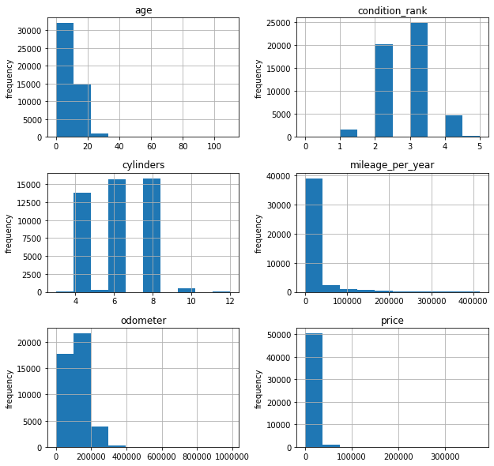

```python
param_graphs = vehicle_ads.hist(['price', 'age', 'odometer', 'mileage_per_year', 'cylinders', 'condition_rank'], figsize=(10, 10))
for axis in param_graphs.flatten():
    axis.set_ylabel('frequency')
plt.show()
```

# **Reviewer Comment**

**Success:** The data is studied in detail

# **Reviewer Comment**

**Recommendation:**

Technical strings like `<matplotlib.axes._subplots.AxesSubplot at 0x7f69fa0023d0>` can be deleted with the use of `plt.show()` method (if it occurs). It will improve the visualization in the project:)

*Conclusion: Outlier impact on readability*

- Columns: mileage_per_year, odometer, age, and price appear to have outliers
  - The graphs have all the data, however the majority of vehicles in each graph are clustered to the left
  - Their bins have a large range so seeing more specific data is difficult
- Columns: condition_rank and cylinders may have outliers but it is not as obvious

# Investigation request:

# Determine the upper limits of outliers, remove the outliers and store them in a separate DataFrame, and continue your work with the filtered data.

*Plan of action*

- Deterine IQR of the columns above (Q3 - Q1)
- Calculate the cut off for outliers using the IQR (Q1/Q3 -/+ 1.5 * IQR)
- Using the IQR information filter the data to exclude outliers

```python
# Create a function to calculate IQR and related stats for columns
def find_outliers(column):
    min_value = column.min()
    max_value = column.max()
    Q1 = column.quantile(0.25)
    Q3 = column.quantile(0.75)
    IQR = Q3 - Q1
    min_whisker = Q1 - 1.5 * IQR
    max_whisker = Q3 + 1.5 * IQR
    print('{} column:\nmin value: {}\nlower iqr: {}\nmax value: {}\nupper iqr: {}'
          .format(column.name, min_value, min_whisker, max_value, max_whisker), '\n')
```

# **Reviewer Comment**

**Success:**

- The IQR method for deleting the outliers was used, it is rather effective one for this task!

Great!🙂

```python
find_outliers(vehicle_ads['price'])
find_outliers(vehicle_ads['condition_rank'])
find_outliers(vehicle_ads['mileage_per_year'])
find_outliers(vehicle_ads['odometer'])
find_outliers(vehicle_ads['age'])
find_outliers(vehicle_ads['cylinders'])
```

```
price column:
min value: 1
lower iqr: -12758.5
max value: 375000
upper iqr: 34597.5

condition_rank column:
min value: 0
lower iqr: 0.5
max value: 5
upper iqr: 4.5

mileage_per_year column:
min value: 0.0
lower iqr: -8723.451923076926
max value: 415371.0
upper iqr: 43546.471153846156

odometer column:
min value: 0.0
lower iqr: -57500.0
max value: 990000.0
upper iqr: 282500.0

age column:
min value: 0.0
lower iqr: -8.0
max value: 110.0
upper iqr: 24.0

cylinders column:
min value: 3.0
lower iqr: -2.0
max value: 12.0
upper iqr: 14.0
```

*Conclusion on results above*

*Plan of action*

- Calculate cut off for upper outliers
- Filter the data to remove upper outliers
- Review the columns after outliers are removed using histograms
- Compare the filtered vs unfiltered histograms

```python
# Create a function that will calculate the upper IQR
def upper_iqr(column):
    Q1 = column.quantile(0.25)
    Q3 = column.quantile(0.75)
    IQR = Q3 - Q1
    max_whisker = Q3 + 1.5 * IQR
    return max_whisker
```

```
price outlier cutoff is 34597.5
filtered price stats:
```

```
count    49879.000000
mean     11095.558472
std       7806.520888
min          1.000000
25%       4995.000000
50%       8990.000000
75%      15900.000000
max      34595.000000
Name: price, dtype: float64
```

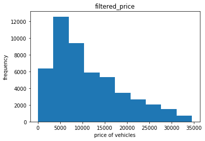

```python
# filtered histogram
price_iqr = upper_iqr(vehicle_ads['price'])
filtered_price = vehicle_ads.query('price <= @price_iqr')
print('price outlier cutoff is {}'.format(price_iqr))
filtered_price['price'].plot(kind='hist', title='filtered_price')
plt.ylabel('frequency')
plt.xlabel('price of vehicles')
print('filtered price stats:')
filtered_price['price'].describe()
```

```
odometer outlier cutoff is 282500.0
filtered odometer stats:
```

```
count     43146.000000
mean     113005.666643
std       59845.354804
min           0.000000
25%       69597.000000
50%      112100.000000
75%      153108.000000
max      282493.000000
Name: odometer, dtype: float64
```

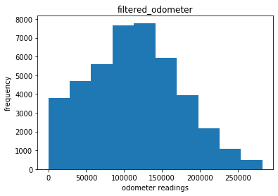

```python
# filtered histogram
odometer_iqr = upper_iqr(vehicle_ads['odometer'])
filtered_odometer = vehicle_ads.query('odometer <= @odometer_iqr')
print('odometer outlier cutoff is {}'.format(odometer_iqr))
filtered_odometer['odometer'].plot(kind='hist', title='filtered_odometer')
plt.ylabel('frequency')
plt.xlabel('odometer readings')
print('filtered odometer stats:')
filtered_odometer['odometer'].describe()
```

```
mileage_per_year outlier cutoff is 43546.471153846156
filtered mileage_per_year stats:
```

```
count    39263.000000
mean     16098.116360
std       8559.115512
min          0.000000
25%      10387.361111
50%      14696.285714
75%      20502.125000
max      43508.000000
Name: mileage_per_year, dtype: float64
```

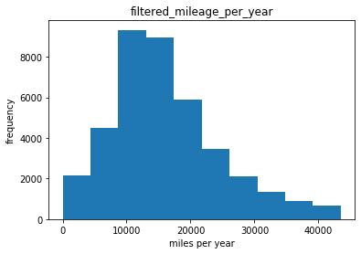

```python
# filtered histogram
mileage_per_year_iqr = upper_iqr(vehicle_ads['mileage_per_year'])
filtered_mileage_per_year = vehicle_ads.query('mileage_per_year <= @mileage_per_year_iqr')
print('mileage_per_year outlier cutoff is {}'.format(mileage_per_year_iqr))
filtered_mileage_per_year['mileage_per_year'].plot(kind='hist', title='filtered_mileage_per_year')
plt.ylabel('frequency')
plt.xlabel('miles per year')
print('filtered mileage_per_year stats:')
filtered_mileage_per_year['mileage_per_year'].describe()
```

```
condition_rank outlier cutoff is 4.5
filtered condition_rank stats:
```

```
count    51382.000000
mean         2.630960
std          0.702437
min          0.000000
25%          2.000000
50%          3.000000
75%          3.000000
max          4.000000
Name: condition_rank, dtype: float64
```

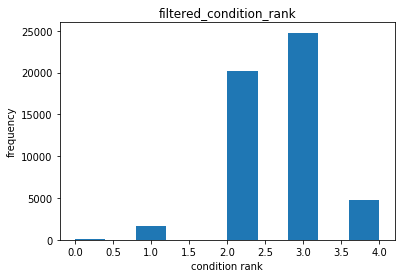

```python
# filtered histogram
condition_rank_iqr = upper_iqr(vehicle_ads['condition_rank'])
filtered_condition_rank = vehicle_ads.query('condition_rank <= @condition_rank_iqr')
print('condition_rank outlier cutoff is {}'.format(condition_rank_iqr))
filtered_condition_rank['condition_rank'].plot(kind='hist', title='filtered_condition_rank')
plt.ylabel('frequency')
plt.xlabel('condition rank')
print('filtered condition_rank stats:')
filtered_condition_rank['condition_rank'].describe()
```

```
age outlier cutoff is 24.0
filtered age stats:
```

```
count    47169.000000
mean         8.157413
std          5.306415
min          0.000000
25%          4.000000
50%          7.000000
75%         12.000000
max         24.000000
Name: age, dtype: float64
```

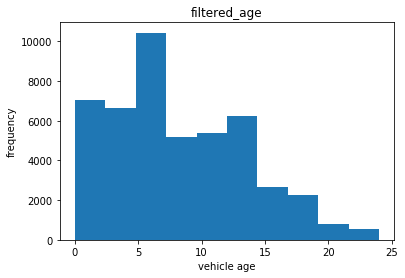

```python
# filtered histogram
age_iqr = upper_iqr(vehicle_ads['age'])
filtered_age = vehicle_ads.query('age <= @age_iqr')
print('age outlier cutoff is {}'.format(age_iqr))
filtered_age['age'].plot(kind='hist', title='filtered_age')
plt.ylabel('frequency')
plt.xlabel('vehicle age')
print('filtered age stats:')
filtered_age['age'].describe()
```

```
cylinders outlier cutoff is 14.0
filtered cylinders stats:
```

```
count    46265.000000
mean         6.125235
std          1.660360
min          3.000000
25%          4.000000
50%          6.000000
75%          8.000000
max         12.000000
Name: cylinders, dtype: float64
```

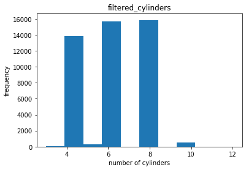

```python
# filtered histogram
cylinders_iqr = upper_iqr(vehicle_ads['cylinders'])
filtered_cylinders = vehicle_ads.query('cylinders <= @cylinders_iqr')
print('cylinders outlier cutoff is {}'.format(cylinders_iqr))
filtered_cylinders['cylinders'].plot(kind='hist', title='filtered_cylinders')
plt.ylabel('frequency')
plt.xlabel('number of cylinders')
print('filtered cylinders stats:')
filtered_cylinders['cylinders'].describe()
```

```python
# Create a table containing the data from all the filtered columns
filtered_data = vehicle_ads.query('price <= @price_iqr and odometer <= @odometer_iqr and mileage_per_year <= @mileage_per_year_iqr and condition_rank <= @condition_rank_iqr and age <= @age_iqr and cylinders <= @cylinders_iqr')

# Examine general info of the filtered data
filtered_data.info()
```

```
<class 'pandas.core.frame.DataFrame'>
Int64Index: 32906 entries, 0 to 51523
Data columns (total 19 columns):
price               32906 non-null int64
model_year          32906 non-null float64
model               32906 non-null object
condition           32906 non-null object
cylinders           32906 non-null float64
fuel                32906 non-null object
odometer            32906 non-null float64
transmission        32906 non-null object
type                32906 non-null object
paint_color         27022 non-null object
is_4wd              32906 non-null int64
date_posted         32906 non-null datetime64[ns]
days_listed         32906 non-null int64
weekday_posted      32906 non-null object
month_posted        32906 non-null int64
year_posted         32906 non-null int64
age                 32906 non-null float64
mileage_per_year    32906 non-null float64
condition_rank      32906 non-null int64
dtypes: datetime64[ns](1), float64(5), int64(6), object(7)
memory usage: 5.0+ MB
```

```
Review filtered vs unfiltered histograms:
```

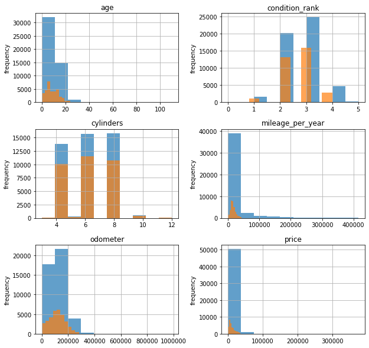

```python
# Review filtered vs unfiltered histograms
print('Review filtered vs unfiltered histograms:')
unfilt_ax = vehicle_ads.hist(['price', 'age', 'odometer', 'mileage_per_year', 'cylinders', 'condition_rank'], figsize=(10, 10), alpha = 0.7)
filtered_data.hist(['price', 'age', 'odometer', 'mileage_per_year', 'cylinders', 'condition_rank'], figsize=(10, 10), ax=unfilt_ax, alpha=0.7)
for axis in unfilt_ax.flatten():
    axis.set_ylabel('frequency')
plt.show()
```

*Conclusion on removing outliers*

- Removing outliers helps create more readable graphs
- Conclusions for each graph:
  - filtered_price:
    - vehicle prices range from 1 to < 35000
    - the median price is 8990, the mean is 11095
    - the graph is right scewed - vehicles priced below the median have a smaller variation in price, while those above the median have a larger variation in price
    - most vehicles are priced between 4995 - 15900
  - filtered_odometer:
    - odometer readings range from 0 to 282493
    - the median (112100) and mean (113005) are similar giving a near Gaussian distribution
    - most vehicles have an odometer reading between 69597 - 153108
  - filtered_mileage_per_year:
    - mileage per year ranges from 0 to 43508
    - the graph follows a similar shape to the filtered odometer readings but is right scewed
      - This is expected because mileage_per_year is a product of the odometer column
    - the median is 14696, the mean is 16098
    - most vehicles have been driven between 10387 - 20502 miles per year
  - filtered_age:
    - vehicle ages range from 0 to 24
    - the median (7) and mean (8.15) are similar suggesting a Gaussian distribution
      - however there is a large amount of vehicles around the age of 7 that may be distorting these values
    - most vehicles are between the age of 4 - 12
  - filtered_cylinders:
    - cylinders range from 3 to 12 (there were no outliers calculated for this column, it's outlier cutoff was 14)
    - the median (6) and mean (6.13) are nearly identical giving a Gaussian distribution
    - most vehicles have 4 - 8 cylinders
  - filtered_condition_rank:
    - conditions range from 0 to 4
    - the median (3) and mean (2.63) are similar giving a near Gaussian distribution
    - most vehicles rank between 2 - 3

# **Reviewer Comment**

**Success:**

- You correctly analysed how outliers affect the distribution,  
  Also there are a lots of informative charts, Great!🙂

# Investigation request:

# Study how many days advertisements were displayed ( days_listed ). Plot a histogram. Calculate the mean and median. Describe the typical lifetime of an ad. Determine when ads were removed quickly, and when they were listed for an abnormally long time

*Plan of action*

- Plot a histogram
- Use .describe() to:
  - Calculate the mean and median
  - Describe the typical lifetime of an ad
    - Determine when ads were removed quickly, and when they were listed for an abnormally long time.

```
unfiltered stats (days_listed):
 count    51525.00000
mean        39.55476
std         28.20427
min          0.00000
25%         19.00000
50%         33.00000
75%         53.00000
max        271.00000
Name: days_listed, dtype: float64
filtered stats (days_listed):
 count    32906.000000
mean        39.668419
std         28.182838
min          0.000000
25%         19.000000
50%         33.000000
75%         53.000000
max        271.000000
Name: days_listed, dtype: float64
```

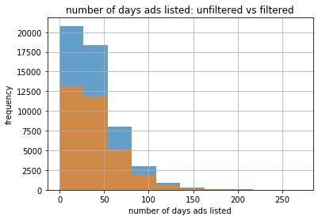

```python
# Plot a histogram comparing the filtered vs unfiltered data of days_listed column
vehicle_ads['days_listed'].hist(alpha=0.7)
print('unfiltered stats (days_listed):\n', vehicle_ads['days_listed'].describe())

filtered_data['days_listed'].hist(alpha=0.7)
print('filtered stats (days_listed):\n', filtered_data['days_listed'].describe())
plt.title('number of days ads listed: unfiltered vs filtered')
plt.xlabel('number of days ads listed')
plt.ylabel('frequency')
plt.show()
```

*Conclusion on days_listed / lifetime of an ad*

- An ad could be posted from 0 to 271 days
- According to this data an ad on average will be posted for 39 days but the median suggests 33 days
- Most ads are posted for less than 53 days

# **Reviewer Comment**

**Success**: Right conclusion!

# **Reviewer Comment. V.1**

**Issue:**

It is common practise to title axes and charts.

Please, **check all charts above\below** and add the common **titles** and **x and y axis labels** to all the graphs in your project:)

It is important because it makes it easier to understand and read the visualization especially for the external observer who is not immersed in the specifics of the project. </s>

# **Student comment/response to comment above**

I hope that the graphs are more readable now!

# **Reviewer Comment V. 2**

**Success:** If chart captions aren't informative, readers may interpret graphs incorrectly. That is why it is so important to properly label a graph :)

The charts are readable and perfect now, thank you!🙂

# Investigation request:

# Analyze the number of ads and the average price for each type of vehicle. Plot a graph showing the dependence of the number of ads on the vehicle type. Select the two types with the greatest number of ads.

*Action Plan*

- create a table containing two columns:
  - the number of ads per vehicle type
  - the average price per vehicle type
- use a scatter plot to show dependence of the number of ads on the vehicle type
- select the two most popular types of vehicles based on number of ads

```python
# Create a table with the number of ads per vehicle type and the average price per type of vehicle
type_table = filtered_data.pivot_table(index='type', values='price', aggfunc=['count', 'mean'])
type_table.columns = ['count', 'avg_price']
print(type_table)
```

```
             count     avg_price
type
SUV           8125  10330.836308
bus             19  15988.736842
convertible    256  12774.835938
coupe         1458  13318.521948
hatchback      683   6486.398243
mini-van       773   7870.235446
offroad        137  14199.832117
other          153  10147.294118
pickup        4283  14820.551483
sedan         8079   6792.872385
truck         7516  14700.327568
van            386   8598.979275
wagon         1038   8756.089595
```

|  | count | avg_price |
| --- | --- | --- |
| count | 1.000000 | -0.033157 |
| avg_price | -0.033157 | 1.000000 |

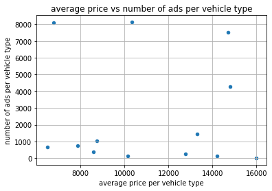

```python
# Create a scatter plot
type_table.plot(kind='scatter', x='avg_price', y='count', grid=True)
plt.title('average price vs number of ads per vehicle type')
plt.xlabel('average price per vehicle type')
plt.ylabel('number of ads per vehicle type')
# Evaluate the correlation of average price to number of ads
type_table.corr()
```

*Conclusion on number of ads and average price per vehicle type*

- SUVs and sedans have the greatest number of ads
- This graph shows there is no dependence on number of ads and average price per vehicle type

# **Reviewer Comment**

**Success:** The two types with the greatest number of ads are **sedan and SUV**: absolutely correct!

# Investigation request:

# What factors impact the price most? Take each of the popular types you detected at the previous stage and study whether the price depends on age, mileage, condition, transmission type, and color. For categorical variables (transmission type and color), plot box-and whisker charts, and create scatterplots for the rest. When analyzing categorical variables, note that the categories must have at least 50 ads; otherwise, their parameters won't be valid for analysis.

*Action Plan*

```python
# Create a table to examine numerical columns of interest
impact_table = filtered_data.query('type == ("SUV", "sedan")').pivot_table(index='price', values=['age', 'mileage_per_year', 'odometer', 'condition_rank'])
# Review the table
print(impact_table.head(10))
```

```
             age  condition_rank  mileage_per_year       odometer
price
1       2.018587        3.022305      17111.070364   31035.148699
9       9.000000        2.000000         13.222222     119.000000
39     10.666667        3.333333       5560.916667   33402.666667
69      1.764706        3.000000      29224.882353   52430.705882
80     14.000000        2.000000      10359.500000  145033.000000
85     10.000000        2.000000      14809.414141  143362.000000
105     7.000000        3.000000      10000.000000   70000.000000
155    10.000000        3.000000      11680.600000  116806.000000
171     0.000000        4.000000      40019.000000   40019.000000
176     8.000000        3.000000      18232.500000  145860.000000
```

```
                       age  condition_rank  mileage_per_year  odometer
age               1.000000       -0.437997         -0.541509  0.771190
condition_rank   -0.437997        1.000000          0.127357 -0.424745
mileage_per_year -0.541509        0.127357          1.000000 -0.065824
odometer          0.771190       -0.424745         -0.065824  1.000000
```

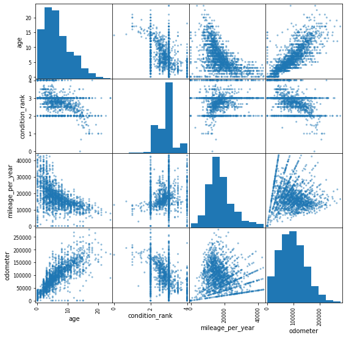

```python
# Examine the correlation coefficients and scatter plots
print(impact_table.corr())
pd.plotting.scatter_matrix(impact_table, figsize=(9, 9))
plt.show()
```

```python
### Removed after code review

# # Create a table to examine categorical columns of interest
# impact_table_paint_color = filtered_data.query('type in ("SUV", "sedan")').pivot_table(index='paint_color', values='price')
# # Review the table
# impact_table_paint_color
```

```python
### Removed after code review

# # Examine the stats and box plot
# print(impact_table_paint_color.describe())
# impact_table_paint_color.boxplot()
```

*Create box plots for categorical data*

- Examine tables of mean and medain for SUV and sedan vehicle types
- Create box plots for each vehicle type:
  - paint color
  - transmission
- Evaluate plots for trends

*SUV paint color and transmission evaluation*

```python
# Create a table based on paint color
suv_paint_query = filtered_data.query('type == "SUV"').pivot_table(index=['type', 'paint_color'], values='price', aggfunc=['mean', 'median'])
suv_paint_query
```

| type | paint_color | mean price | median price |
| --- | --- | --- | --- |
| SUV | black | 11798.272411 | 9997.0 |
|  | blue | 8383.912072 | 6950.0 |
|  | brown | 8576.478992 | 7493.5 |
|  | custom | 9220.461905 | 8347.5 |
|  | green | 7962.384880 | 5995.0 |
|  | grey | 10346.751948 | 8499.0 |
|  | orange | 16024.226415 | 16900.0 |
|  | purple | 6373.360000 | 4995.0 |
|  | red | 9708.019200 | 7900.0 |
|  | silver | 9692.874405 | 7999.0 |
|  | white | 11390.232800 | 9650.0 |
|  | yellow | 14803.571429 | 13694.0 |

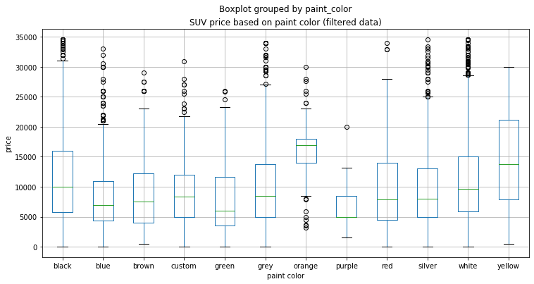

```python
# Create box plots based on paint color
filtered_data[filtered_data['type'] == 'SUV'].boxplot(column='price', by= 'paint_color', figsize=(12,6))
plt.title('SUV price based on paint color (filtered data)')
plt.xlabel('paint color')
plt.ylabel('price')
plt.show()
```

```python
# Create a table based on transmission type
suv_transm_query = filtered_data.query('type == "SUV"').pivot_table(index=['type', 'transmission'], values='price', aggfunc=['mean', 'median'])
suv_transm_query
```

| type | transmission | mean price | median price |
| --- | --- | --- | --- |
| SUV | automatic | 10303.411551 | 8495 |
|  | manual | 11752.107595 | 10995 |
|  | other | 8044.163462 | 7945 |

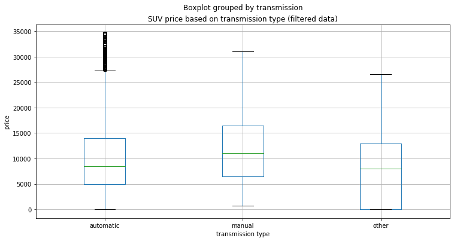

```python
filtered_data[filtered_data['type'] == 'SUV'].boxplot(column='price', by= 'transmission', figsize=(12,6))
plt.title('SUV price based on transmission type (filtered data)')
plt.xlabel('transmission type')
plt.ylabel('price')
plt.show()
```

*sedan paint color and transmission evaluation*

```python
# Create a table based on paint color
sedan_paint_query = filtered_data.query('type == "sedan"').pivot_table(index=['type', 'paint_color'], values='price', aggfunc=['mean', 'median'])
sedan_paint_query
```

| type | paint_color | mean price | median price |
| --- | --- | --- | --- |
| sedan | black | 7328.085418 | 6500.0 |
|  | blue | 6497.471154 | 5699.0 |
|  | brown | 5003.505882 | 4050.0 |
|  | custom | 5762.854839 | 4995.0 |
|  | green | 4406.117647 | 3772.5 |
|  | grey | 6864.052729 | 5995.0 |
|  | orange | 9735.000000 | 8902.0 |
|  | purple | 6609.823529 | 6000.0 |
|  | red | 6895.761240 | 5990.0 |
|  | silver | 6669.738043 | 5888.0 |
|  | white | 7345.256809 | 6500.0 |
|  | yellow | 6340.750000 | 4474.5 |

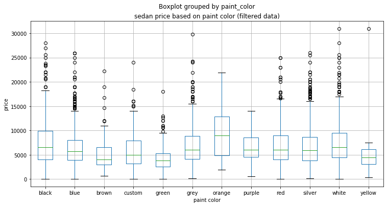

```python
# Create box plots based on paint color
filtered_data[filtered_data['type'] == 'sedan'].boxplot(column='price', by= 'paint_color', figsize=(12,6))
plt.title('sedan price based on paint color (filtered data)')
plt.xlabel('paint color')
plt.ylabel('price')
plt.show()
```

```python
# Create a table based on transmission type
sedan_transm_query = filtered_data.query('type == "sedan"').pivot_table(index=['type', 'transmission'], values='price', aggfunc=['mean', 'median'])
sedan_transm_query
```

| type | transmission | mean price | median price |
| --- | --- | --- | --- |
| sedan | automatic | 6903.942239 | 5995 |
|  | manual | 5372.239295 | 4495 |
|  | other | 3982.252525 | 3700 |

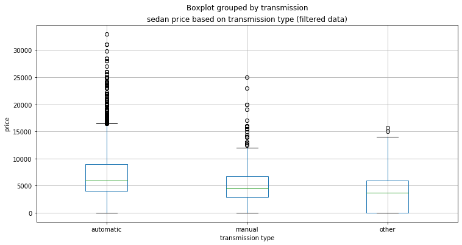

```python
filtered_data[filtered_data['type'] == 'sedan'].boxplot(column='price', by= 'transmission', figsize=(12,6))
plt.title('sedan price based on transmission type (filtered data)')
plt.xlabel('transmission type')
plt.ylabel('price')
plt.show()
```

*Conclusion on price and parameters of interest*

Based on the price of SUVs and sedans:

- Numerical columns (scatter plots)
  - age & odometer: highest postitive correlation
    - as a vehicle gets older, it is likely to have more miles
  - age & mileage_per_year: highest negative correlation
    - as a vehicle gets older, it is likely to have more miles, but the mileage is spread out over more years. So the less miles per year, the older the car is likely to be.
  - age & condition_rank: negative correlation
    - the younger the car, the higher the rank. the older the car, the lower the rank.
  - odometer & conditoin_rank: negative correlation
    - cars with more total miles are more likely to have lower ranks
  - little to no trends:
    - condition_rank & mileage_per_year
    - odometer & mileage_per_year

*Conclusions before code review*

- Categorical columns (box plots)
  - paint_color
    - based on paint color most SUVs and sedans on average are likely to be priced between 7276 - 9624
    - the median price is 8133 which is lower than the mean at 8902 - this is likely due to the outlier
  - transmission type
    - based on transmission type most SUVs and sedans on average are likely to be priced between 7131 - 8408
    - the median price is 8199 which is higher than the mean at 7626, suggesting that there are more vehicles priced at the lower end of the price points

# **Reviewer Comment**

**Issue:**

In order to study what color (transmission type) impact the price most it is highly important to create a boxplot **for each type of color**.

The following example can be usefull to build an informative chart at this step of analysis:

```
`filtered_data[filtered_data['type'] == 'SUV'].boxplot(column='price', by= 'paint_color', figsize=(12,6))`
```

Please, plot box-and-whisker charts for each type of color (and transmission) :) </s>

# **Student comment/response to comment above:**

Thank you for the example of how to properly analyze categorical data. I hope it is correct now!

Thank you for all your feedback and tips, I will do better to incorporate these next time.

# **Reviewer Comment. V.2**

**Success:** Now we see excellent graphs and detailed correct findings!👍 Thank you too, the project is really well done:)

# **Reviewer Comment. V.2**

**Recommendation:** Please, note that we can avoid warnings (if necessary) by using the code below.

```
`import sys
 import warnings
 if not sys.warnoptions:
   warnings.simplefilter("ignore")`
```

```python
### Removed after code review

# # Create a table to examine numerical columns of interest
# impact_table_transmission = filtered_data.query('type == ("SUV", "sedan")').pivot_table(index='transmission', values='price')
# # Review the table
# impact_table_transmission.columns = ['avg_price']
# impact_table_transmission
```

```python
### Removed after code review

# # Examine the stats and box plot
# impact_table_transmission.boxplot()
# print(impact_table_transmission.describe())
```

# **Reviewer Comment**

**Success:**

- The conclusion is clear and logical, and most importantly, it is supported by the revealed facts, good!🙂

## Overall conclusion

- removing the outliers gave more readable data
- most ads are posted for less than 53 days
- SUVs and sedans had the largest amount of ads
  - based on these two vehicle types:
    - there is a positive correlation between age and total mileage suggesting that these two parameters impact the price of a vehicle

While it is out of the scope of this project/instructions, based on the data from these instructions, I would suggest the investigators take a closer look at the vehicle type. This may provide a stronger parameter to determine price.

*Conclusions after code review*

[output not shown]

# **Reviewer Comment. V.2**

**Success:** Now the overall conclusion is more correct. You are very good at analyzing complex data and making right hypotheses, keep it up!

# **Reviewer Comment**

**Success:**

The overall conclusion is clear and correct!

# **Reviewer Comment**

**Recommendation:** For a real life report it would be great to write **all steps** in a structured way. For example:

1. **In the data's preparation & processing stage**:
   - We observed missing values ..;
   - We removed duplicates..
2. **In the exploratory data analysis stage**: *
3. etc.

# Project completion checklist

Mark the completed tasks with 'x'. Then press Shift+Enter.

- [x] file opened
- [x] files explored (first rows printed, info() method)
- [x] missing values determined
- [x] missing values filled in
- [x] clarification of the discovered missing values provided
- [x] data types converted
- [x] explanation of which columns had the data types changed and why
- [x] calculated and added to the table: day of the week, month, and year the ad was placed
- [x] calculated and added to the table: the vehicle's age (in years) when the ad was placed
- [x] calculated and added to the table: the vehicle's average mileage per year
- [x] the following parameters investigated: price, vehicle's age when the ad was placed, mileage, number of cylinders, and condition
- [x] histograms for each parameter created
- [x] task completed: "Determine the upper limits of outliers, remove the outliers and store them in a separate DataFrame, and continue your work with the filtered data."
- [x] task completed: "Use the filtered data to plot new histograms. Compare them with the earlier histograms (the ones that included outliers). Draw conclusions for each histogram."
- [x] task completed: "Study how many days advertisements were displayed (days_listed). Plot a histogram. Calculate the mean and median. Describe the typical lifetime of an ad. Determine when ads were removed quickly, and when they were listed for an abnormally long time. "
- [x] task completed: "Analyze the number of ads and the average price for each type of vehicle. Plot a graph showing the dependence of the number of ads on the vehicle type. Select the two types with the greatest number of ads. "
- [x] task completed: "What factors impact the price most? Take each of the popular types you detected at the previous stage and study whether the price depends on age, mileage, condition, transmission type, and color. For categorical variables (transmission type and color), plot box-and-whisker charts, and create scatterplots for the rest. When analyzing categorical variables, note that the categories must have at least 50 ads; otherwise, their parameters won't be valid for analysis. "
- [x] each stage has a conclusion
- [x] overall conclusion drawn

# Troubleshooting notes - Code reviewer please ignore

- when trying to change model_year to a datetime object, it became weird objects that ultimately did not work for calculating the age of the vehicles posted
- AttributeError: 'Timestamp' object has no attribute 'dt'
  - this error seemed to be happening bc i didnt make a new column for the attribute to work on - I think bc it wanted to be iterated over
- In the end I found that I can subtract a float object from a datetime or timestamp object
  - it returns a float value or a NaN but the calculation works...

```python
###                                              ***TROUBLESHOOTING***
# df = pd.read_csv('/datasets/vehicles_us.csv')

# # changed column data type to datetime
# df['date_posted'] = pd.to_datetime(df['date_posted']) # no format added
# print('type after date_posted to datetime:', type(df['date_posted'])) # the column is a series object
# print('first row of changed data type:', type(df['date_posted'][0])) # each row is a timestamp object
# df.info()

# # create new columns so that .dt.method_name will work on newly changed datetime column (need new column for the methods)
# df['weekday_posted'] = df['date_posted'].dt.day_name()
# print(df['weekday_posted'])
# # Create a new column to extract the year from the datetime object
# df['year_posted'] = df['date_posted'].dt.year
# print('first row of year posted:', df['year_posted'][0])

# # see if i can subtract a float object from a datetime object
# # returns a float as the age, but the caluclation works...
# df['car_age'] = df['year_posted'] - df['model_year']
# print('first row of age:', df['car_age'][0])
# print('type of age data:', type(df['car_age'][0])) # = <class 'numpy.float64'>

# # do the same for the model_year column which has a float data type and only has a year value
# df['make_year'] = pd.to_datetime(df['model_year']) # no format added
# df.info()
# # this changes the datatype but makes a weird object that doesnt make sense to me... 1970-01-01 00:00:00.000002011
# # and the datetime method .year gives the wrong value
# print('first row of model_year w/o format:', df['make_year'][0])
# print('year method applied to non-formated model_year:', df['make_year'][0].year)

# # if I try to add a format parameter, it produces a more readable object: 2011-01-01 00:00:00 but is not what I want
# # again the datetime methods dont work on this object
# df['make_year_form'] = pd.to_datetime(df['model_year'], format='%Y')
# df.info()
# print('first row of formated model_year:', df['make_year_form'][0].year)
# print('type of formated model_year:', type(df['make_year_form']))
# print('year method applied to formated model_year:', df['make_year_form'][0].year)

# df['age_posted'] = df['year_posted'] - df['make_year']
# # gives this error: UFuncTypeError: ufunc 'subtract' cannot use operands with types dtype('int64') and dtype('<M8[ns]')
# print(df['age_posted'][0])

# df['age_posted_form'] = df['year_posted'] - df['make_year_form']
# # gives this error: UFuncTypeError: ufunc 'subtract' cannot use operands with types dtype('int64') and dtype('<M8[ns]')
# print(df['age_posted_form'][0])

# df.head()
```